# statInferenceReport2

BMc

Saturday, February 21, 2015

## Overview

The purpose of this report is to analyze the ToothGrowth data from the R datasets package and state any conclusions which can be drawn.

In this case, an analysis was done specifically to determine the better delivery option for vitamin C to stimulate growth of teeth in guinea pigs: orange juice or ascorbic acid.

## Data Summary

```
Load the ToothGrowth data and perform some basic exploratory data analyses
Provide a basic summary of the data.
Use confidence intervals and/or hypothesis tests to compare tooth growth by supp and dose. (Only use the techniques from class, even if there's other approaches worth considering)
State your conclusions and the assumptions needed for your conclusions.
```

```r
library(ggplot2)
head(ToothGrowth)
```

```
##    len supp dose
## 1  4.2   VC  0.5
## 2 11.5   VC  0.5
## 3  7.3   VC  0.5
## 4  5.8   VC  0.5
## 5  6.4   VC  0.5
## 6 10.0   VC  0.5
```

```r
summary(ToothGrowth)
```

```
##       len        supp         dose
##  Min.   : 4.20   OJ:30   Min.   :0.500
##  1st Qu.:13.07   VC:30   1st Qu.:0.500
##  Median :19.25           Median :1.000
##  Mean   :18.81           Mean   :1.167
##  3rd Qu.:25.27           3rd Qu.:2.000
##  Max.   :33.90           Max.   :2.000
```

## Comparison of tooth growth

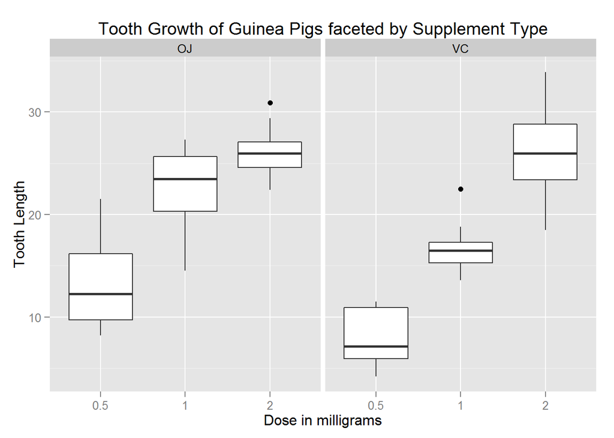

```r
data_plot <- ggplot(ToothGrowth, aes(factor(dose),len))
data_plot <- data_plot + geom_boxplot() + facet_grid(. ~ supp) + labs(title="Tooth Growth of Guinea Pigs faceted by Supplement Type", x="Dose in milligrams", y="Tooth Length")
data_plot
```

```r
var(ToothGrowth[ToothGrowth$dose == 2 & ToothGrowth$supp == "VC",1])
```

```
## [1] 23.01822
```

```r
var(ToothGrowth[ToothGrowth$dose == 2 & ToothGrowth$supp == "OJ",1])
```

```
## [1] 7.049333
```

As shown above, the tooth growth for lower doses of OJ is much higher than the comparable amount for Ascorbic Acid, with up to three quarters of the readings showing longer tooth length in guinea pigs getting vitamin C from orange juice. However, at a dose of 2 mg, the readings for ascorbic acid show a larger range which may indicate a better delivery mechanism than the comparable amount delivered via orange juice. Unfortunately, due to higher variability, this may not be ideal in a test environment if an expected growth amount is required.

## Assumptions for conclusion

It is assumed that the data points collected are independent random variables.